# Practical Machine Learning Course Project

Daniel De Leonardis

12 August 2017

## Executive Summary

Using devices such as Jawbone Up, Nike FuelBand, and Fitbit it is now possible to collect a large amount of data about personal activity relatively inexpensively. These type of devices are part of the quantified self movement - a group of enthusiasts who take measurements about themselves regularly to improve their health, to find patterns in their behavior, or because they are tech geeks. One thing that people regularly do is quantify how much of a particular activity they do, but they rarely quantify how well they do it.

In this project, the goal is to use data from accelerometers on the belt, forearm, arm, and dumbell of 6 participants. They were asked to perform barbell lifts correctly and incorrectly in 5 different ways.

More information is available from the website here: http://web.archive.org/web/20161224072740/http:/groupware.les.inf.puc-rio.br/har (see the section on the Weight Lifting Exercise Dataset).

The goal is to predict the manner in which the participants did the exercise using the “classe” variable.

The data was partitioned into training and test data sets and trained against various models with the random forest model producing the best preduction with an out of sample error rate of less than 1%.

## Data Preparation

The training data for this project are available here: https://d396qusza40orc.cloudfront.net/predmachlearn/pml-training.csv

The test data are available here: https://d396qusza40orc.cloudfront.net/predmachlearn/pml-testing.csv

```r
library(caret)
library(randomForest)
```

There are two data sets to load. The first is the training data set that will be partitioned into the model training and test data and the second is the data set that will be used to predict the values used in the Course Project Prediction Quiz for automated grading.

There are a number of fields that contain missing or invalid values. These are set to NA when the data sets are loaded.

```r
setwd("F:/Documents/Programming/R/data/har/")
trainingData <- read.csv("pml-training.csv", na.strings=c("NA","#DIV/0!",""))
quizTestData <- read.csv("pml-testing.csv", na.strings=c("NA","#DIV/0!",""))
```

A number of columns are removed from the data sets including those that are not relevant to train the models e.g. user names and timestamps, and the columns which are predominantly NA. This leaves 53 columns in the data set with the 53rd column being the outcome variable classe.

```r
trainingData <- trainingData[, -c(1:7)]
quizTestData <- quizTestData[, -c(1:7)]
trainingData <- trainingData[, colSums(is.na(trainingData)) == 0]
quizTestData <- quizTestData[, colSums(is.na(quizTestData)) == 0]

dim(trainingData)
```

```
## [1] 19622    53
```

```r
dim(quizTestData)
```

```
## [1] 20 53
```

The training data set is partitioned into the portion (60%) to be used for training the model and the remainder (40%) to test the model.

```r
set.seed(111)
train <- createDataPartition(trainingData$classe, p = 0.6, list = FALSE)
training <- trainingData[train,]
testing <- trainingData[-train,]
```

A final check is performed on the data to determine which columns are highly correlated. These (5) columns are removed to remove pair-wise correlations from the data sets.

```r
correl <- findCorrelation(cor(training[, -53]))
training <- training[, -correl]
testing <- testing[, -correl]
quizTestData <- quizTestData[, -correl]
dim(training)
```

```
## [1] 11776    48
```

## Model Selection

```r
ctrl <- trainControl(method = "repeatedcv", number = 5, repeats = 5, allowParallel=TRUE)
fitRf <- randomForest(classe ~ ., data = training, trControl = ctrl)
predRfTrain <- predict(fitRf, training)
confusionMatrix(predRfTrain, training$classe)
```

```
## Confusion Matrix and Statistics
##
##           Reference
## Prediction    A    B    C    D    E
##          A 3348    0    0    0    0
##          B    0 2279    0    0    0
##          C    0    0 2054    0    0
##          D    0    0    0 1930    0
##          E    0    0    0    0 2165
##
## Overall Statistics
##
##                Accuracy : 1
##                  95% CI : (0.9997, 1)
##     No Information Rate : 0.2843
##     P-Value [Acc > NIR] : < 2.2e-16
##
##                   Kappa : 1
##  Mcnemar's Test P-Value : NA
##
## Statistics by Class:
##
##                      Class: A Class: B Class: C Class: D Class: E
## Sensitivity            1.0000   1.0000   1.0000   1.0000   1.0000
## Specificity            1.0000   1.0000   1.0000   1.0000   1.0000
## Pos Pred Value         1.0000   1.0000   1.0000   1.0000   1.0000
## Neg Pred Value         1.0000   1.0000   1.0000   1.0000   1.0000
## Prevalence             0.2843   0.1935   0.1744   0.1639   0.1838
## Detection Rate         0.2843   0.1935   0.1744   0.1639   0.1838
## Detection Prevalence   0.2843   0.1935   0.1744   0.1639   0.1838
## Balanced Accuracy      1.0000   1.0000   1.0000   1.0000   1.0000
```

```r
predRfTest <- predict(fitRf, testing)
confusionMatrix(predRfTest, testing$classe)
```

```
## Confusion Matrix and Statistics
##
##           Reference
## Prediction    A    B    C    D    E
##          A 2230   18    0    0    0
##          B    2 1493    8    0    0
##          C    0    7 1358   19    1
##          D    0    0    2 1266    0
##          E    0    0    0    1 1441
##
## Overall Statistics
##
##                Accuracy : 0.9926
##                  95% CI : (0.9905, 0.9944)
##     No Information Rate : 0.2845
##     P-Value [Acc > NIR] : < 2.2e-16
##
##                   Kappa : 0.9906
##  Mcnemar's Test P-Value : NA
##
## Statistics by Class:
##
##                      Class: A Class: B Class: C Class: D Class: E
## Sensitivity            0.9991   0.9835   0.9927   0.9844   0.9993
## Specificity            0.9968   0.9984   0.9958   0.9997   0.9998
## Pos Pred Value         0.9920   0.9933   0.9805   0.9984   0.9993
## Neg Pred Value         0.9996   0.9961   0.9985   0.9970   0.9998
## Prevalence             0.2845   0.1935   0.1744   0.1639   0.1838
## Detection Rate         0.2842   0.1903   0.1731   0.1614   0.1837
## Detection Prevalence   0.2865   0.1916   0.1765   0.1616   0.1838
## Balanced Accuracy      0.9979   0.9910   0.9943   0.9921   0.9996
```

```r
missClass = function(values, prediction) {
    sum(prediction != values)/length(values)
}
missClass(training$classe, predRfTrain)
```

```
## [1] 0
```

```r
missClass(testing$classe, predRfTest)
```

```
## [1] 0.007392302
```

## Predict Classe for the (Quiz) Test Data Set

The following shows the predicted classe values for the quiz data set corresponing to each quiz question.

```r
predict(fitRf, quizTestData)
```

```
##  1  2  3  4  5  6  7  8  9 10 11 12 13 14 15 16 17 18 19 20
##  B  A  B  A  A  E  D  B  A  A  B  C  B  A  E  E  A  B  B  B
## Levels: A B C D E
```

## Conclusion

Using a random forest model we are able to acheive an accuracy of over 99% in predicting the classe value in our test data set.

## Appendix A - Other Models Trained & Tested

### Generalised Boost Regression Model (GBM)

```r
fitBoost <- train(classe ~ ., data=training, method="gbm", verbose = FALSE, trControl = ctrl)
predBoost <- predict(fitBoost, testing)
confusionMatrix(predBoost, testing$classe)$overall[1]
```

```
##  Accuracy
## 0.9588325
```

```r
predict(fitBoost, quizTestData)
```

```
##  [1] B A B A A E D B A A B C B A E E A B B B
## Levels: A B C D E
```

### Linear Discriminant Analysis (LDA) Model

```r
fitLda <- train(classe ~ ., data=training, method="lda", trControl = ctrl)
predLda <- predict(fitLda, testing)
confusionMatrix(predLda, testing$classe)$overall[1]
```

```
## Accuracy
## 0.669768
```

```r
predict(fitLda, quizTestData)
```

```
##  [1] B A A C A C D D A A D A B A E A A B B B
## Levels: A B C D E
```

### Support Vector Machine (SVM) Model

```r
library(e1071)
fitSvm <- svm(classe ~ ., data=training)
predSvm <- predict(fitSvm, testing)
confusionMatrix(predSvm, testing$classe)$overall[1]
```

```
##  Accuracy
## 0.9430283
```

```r
predict(fitSvm, quizTestData)
```

```
##  1  2  3  4  5  6  7  8  9 10 11 12 13 14 15 16 17 18 19 20
##  B  A  A  A  A  E  D  B  A  A  A  C  B  A  E  E  A  B  B  B
## Levels: A B C D E
```

## Appendix B - Random Forest Cross-Validation

```r
cvResult <- rfcv(training[, -48], training$classe, cv.fold = 5)
cvResult$error.cv
```

```
##          47          24          12           6           3           1
## 0.008406929 0.011803668 0.015709918 0.051970109 0.114555027 0.568868886
```

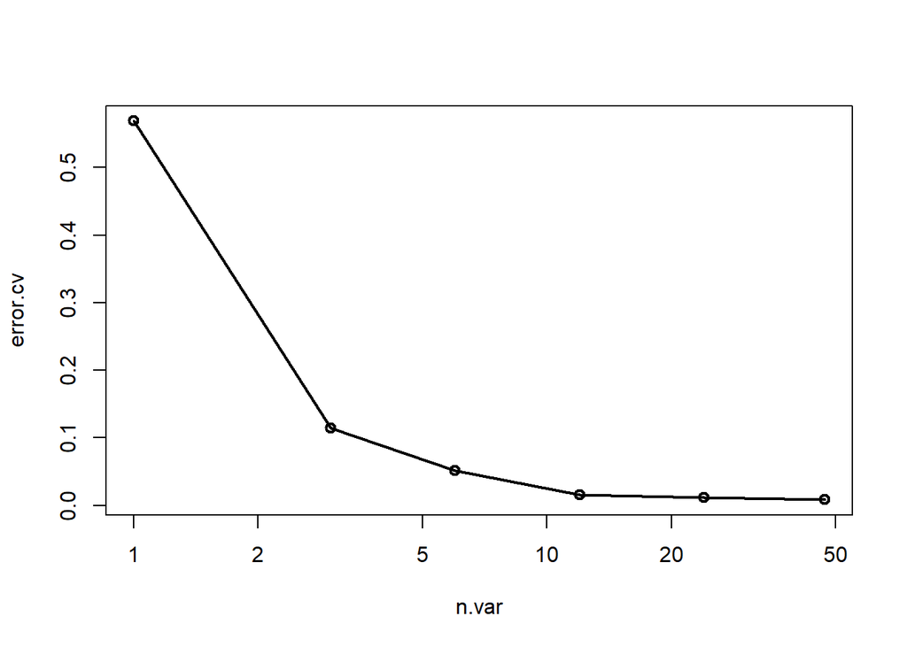

```r
with(cvResult, plot(n.var, error.cv, log="x", type="o", lwd=2))
```